# Time_Series_Project_Including the Covid Data

Lohit Marla

2024-04-29

Now consider the covid data as well where I have added a new variable call covid_indicator manually which indicates the covid effect.

```r
library(janitor)
library(tidyverse)
library(tseries)
library(dplyr)
library(zoo)
library(forecast)
library(astsa)
library(TSA)
tsi_data <- read_csv("With_covid_indicator.csv")
```

```
## ──────────────────────────────────────────────────────── Delimiter: "," chr
## (1): OBS_DATE dbl (2): TSI_Total, Covid indicator lgl (4): ...4, ...5, ...6,
## ...7
```

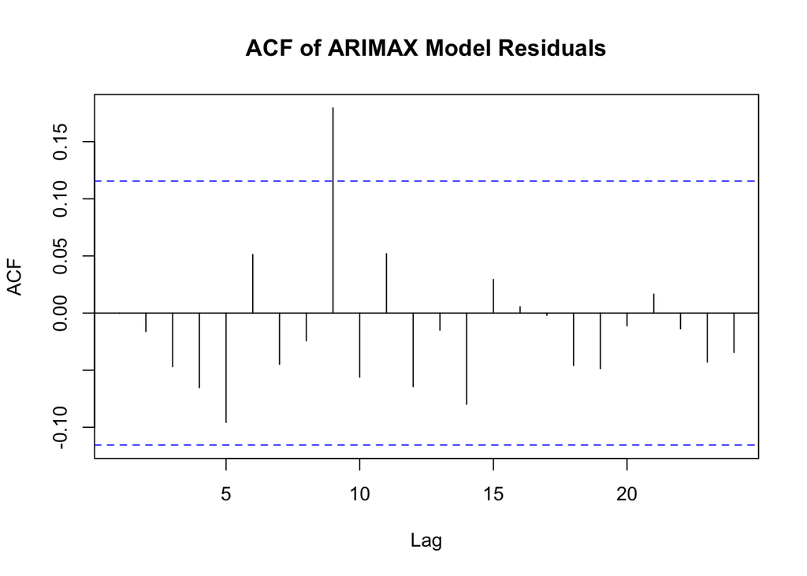

```r
tsi_data <- clean_names(tsi_data)
# Assuming your data frame is named 'tsi_data'
# Convert 'OBS_DATE' to a Date object if it's not already
tsi_data$obs_date <- as.Date(tsi_data$obs_date)

# Fit ARIMAX model with the original time series
arimax_model <- arima(tsi_data$tsi_total, order = c(1, 1, 1), xreg = tsi_data[, "covid_indicator"])

# Plot ACF of residuals
residuals <- residuals(arimax_model)
acf(residuals, main = "ACF of ARIMAX Model Residuals")
```

From the above arimax model which was fitted based on the exogenous variable called covid_indicator there is no effect of it and also the residuals indicates that there is significant lags

```r
arimax_model <- arima((tsi_data$tsi_total), order = c(1, 1, 1))

# Summary of the ARIMAX model
summary(arimax_model)
```

```
##
## Call:
## arima(x = (tsi_data$tsi_total), order = c(1, 1, 1))
##
## Coefficients:
##           ar1     ma1
##       -0.0296  0.4940
## s.e.   0.1153  0.0978
##
## sigma^2 estimated as 5.902:  log likelihood = -662.11,  aic = 1328.21
##
## Training set error measures:
```

```
##               ME RMSE MAE MPE MAPE
## Training set NaN  NaN NaN NaN  NaN
```

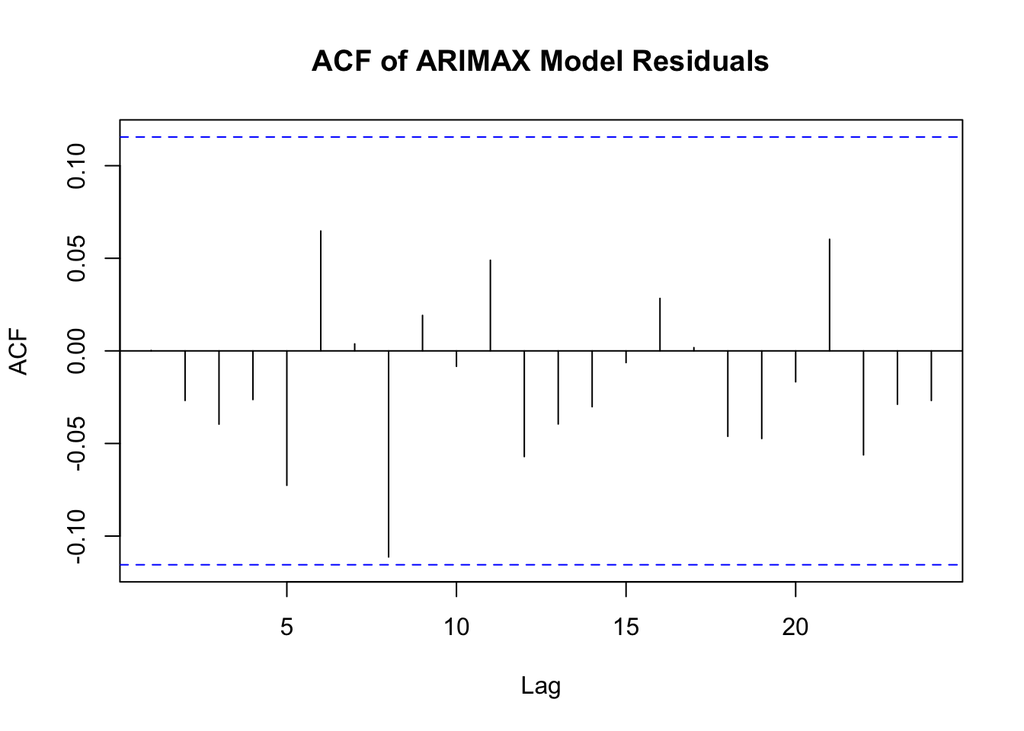

```r
residuals <- residuals(arimax_model)

acf(residuals, main = "ACF of ARIMAX Model Residuals", na.action = na.pass)
```

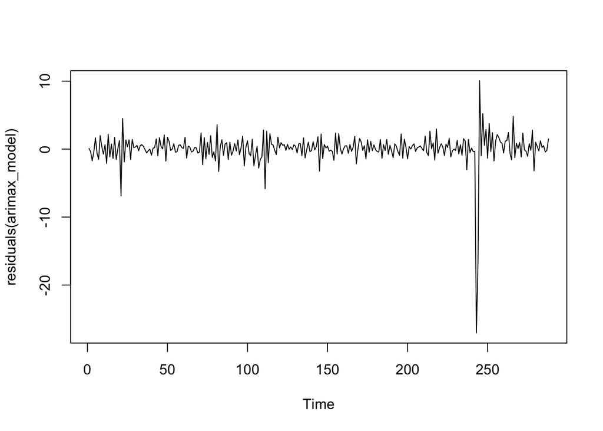

```r
plot(residuals(arimax_model))
```

From the visual inspection of the autocorrelation function (ACF) plot of the residuals, it can be determined that the residuals exhibit desirable characteristics. Specifically, the ACF plot demonstrates a lack of significant autocorrelation at various lags, indicating that the residuals are relatively uncorrelated and exhibit no systematic patterns. This suggests that the ARIMA model adequately captures the temporal dependence in the data, and the residuals display randomness, meeting one of the key assumptions of the model.

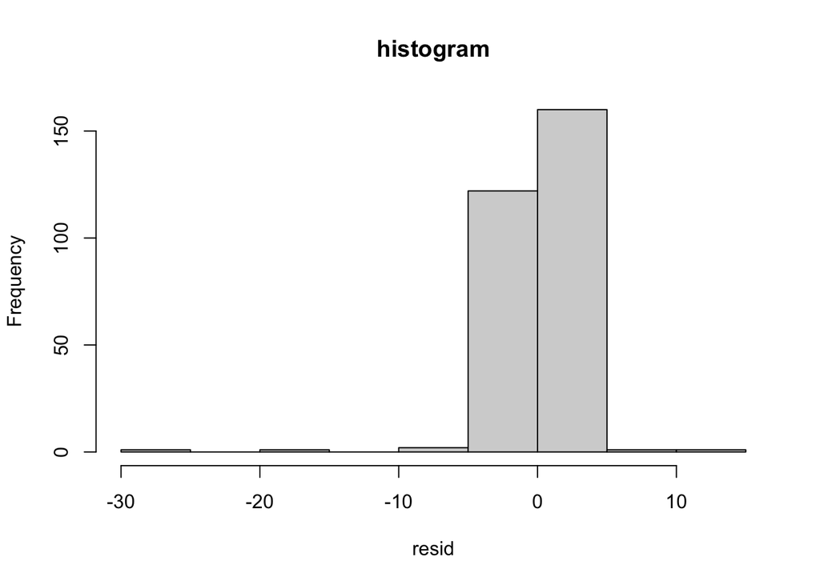

```r
# Remove missing values from residuals
clean_residuals <- residuals[!is.na(residuals)]


residuals <- clean_residuals

hist(residuals,main="histogram",xlab="resid")
```

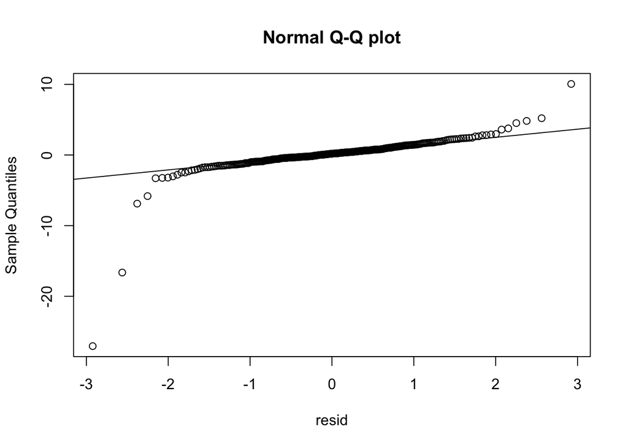

```r
qqnorm(residuals,main="Normal Q-Q plot",xlab="resid"); qqline(residuals)
```

```r
shapiro.test(residuals)
```

```
##
##  Shapiro-Wilk normality test
##
## data:  residuals
## W = 0.58546, p-value < 2.2e-16
```

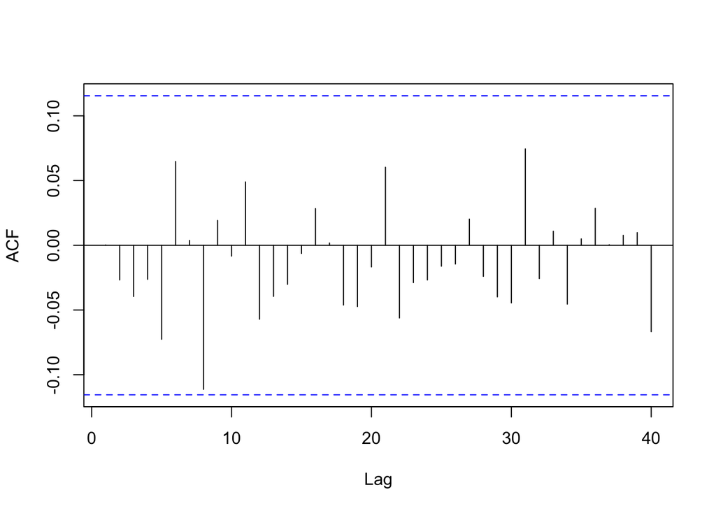

```r
acf(as.numeric(residuals), lag.max=40, main="")
```

```r
Box.test(residuals, lag=4, fitdf=1)
```

```
##
##  Box-Pierce test
##
## data:  residuals
## X-squared = 0.85623, df = 3, p-value = 0.836
```

```r
Box.test(residuals, lag=8, fitdf=1)
```

```
##
##  Box-Pierce test
##
## data:  residuals
## X-squared = 7.1527, df = 7, p-value = 0.4132
```

```r
Box.test(residuals, lag=4, type="Ljung", fitdf=1)
```

```
##
##  Box-Ljung test
##
## data:  residuals
## X-squared = 0.87123, df = 3, p-value = 0.8324
```

```r
rec.yw.fore <- predict(arimax_model, n.ahead=48)
rec.yw.fore
```

```
## $pred
## Time Series:
## Start = 289
## End = 336
## Frequency = 1
##  [1] 128.5909 128.5705 128.5711 128.5711 128.5711 128.5711 128.5711 128.5711
##  [9] 128.5711 128.5711 128.5711 128.5711 128.5711 128.5711 128.5711 128.5711
## [17] 128.5711 128.5711 128.5711 128.5711 128.5711 128.5711 128.5711 128.5711
## [25] 128.5711 128.5711 128.5711 128.5711 128.5711 128.5711 128.5711 128.5711
## [33] 128.5711 128.5711 128.5711 128.5711 128.5711 128.5711 128.5711 128.5711
## [41] 128.5711 128.5711 128.5711 128.5711 128.5711 128.5711 128.5711 128.5711
##
## $se
## Time Series:
## Start = 289
## End = 336
## Frequency = 1
##  [1]  2.429324  4.307842  5.565691  6.588118  7.471913  8.261698  8.982307
##  [8]  9.649250 10.272985 10.860957 11.418694 11.950429 12.459492 12.948557
## [15] 13.419810 13.875067 14.315854 14.743468 15.159025 15.563490 15.957707
## [22] 16.342417 16.718277 17.085870 17.445720 17.798296 18.144021 18.483282
## [29] 18.816426 19.143773 19.465617 19.782225 20.093845 20.400706 20.703019
## [36] 21.000980 21.294773 21.584567 21.870522 22.152785 22.431498 22.706789
## [43] 22.978783 23.247594 23.513333 23.776101 24.035998 24.293114
```

Despite the apparent adequacy of the residuals observed in the autocorrelation function (ACF) plot, further examination using the Shapiro-Wilk test, histograms, and Q-Q plots reveals that the residuals do not conform to a normal distribution. These diagnostic tests suggest departures from normality, indicating potential limitations in the model’s ability to fully capture the underlying variability in the data.

Following is the forecast plot based on the above predictions

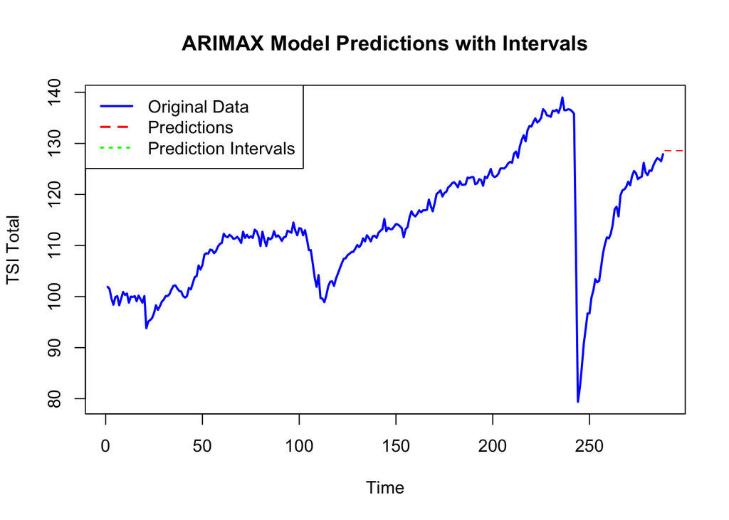

```r
# Plot original data
plot(tsi_data$tsi_total, type = "l", col = "blue", lwd = 2,
     xlab = "Time", ylab = "TSI Total", main = "ARIMAX Model Predictions with Intervals")

# Add predictions
lines(rec.yw.fore$pred, col = "red", lty = 2)


# Add legend
legend("topleft", legend = c("Original Data", "Predictions", "Prediction Intervals"),
       col = c("blue", "red", "green"), lty = c(1, 2, 3), lwd = 2, bg = "white")
```

```r
auto.arima(tsi_data$tsi_total)
```

```
## Series: tsi_data$tsi_total
## ARIMA(1,1,2)
##
## Coefficients:
##          ar1      ma1      ma2
##       0.9266  -0.4915  -0.4794
## s.e.  0.0324   0.0547   0.0502
##
## sigma^2 = 5.844:  log likelihood = -659.41
## AIC=1326.81   AICc=1326.95   BIC=1341.45
```

```r
arimax_model <- arima((tsi_data$tsi_total), order = c(1, 1, 2))

# Summary of the ARIMAX model
summary(arimax_model)
```

```
##
## Call:
## arima(x = (tsi_data$tsi_total), order = c(1, 1, 2))
##
## Coefficients:
##          ar1      ma1      ma2
##       0.9266  -0.4915  -0.4794
## s.e.  0.0324   0.0547   0.0502
##
## sigma^2 estimated as 5.783:  log likelihood = -659.41,  aic = 1324.81
##
## Training set error measures:
```

```
##               ME RMSE MAE MPE MAPE
## Training set NaN  NaN NaN NaN  NaN
```

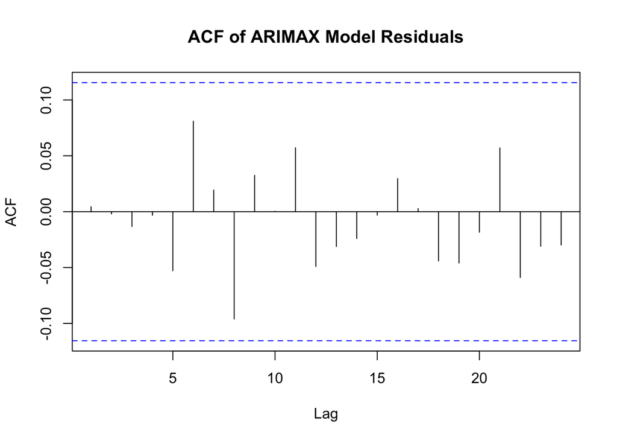

```r
residuals <- residuals(arimax_model)
acf(residuals, main = "ACF of ARIMAX Model Residuals", na.action = na.pass)
```

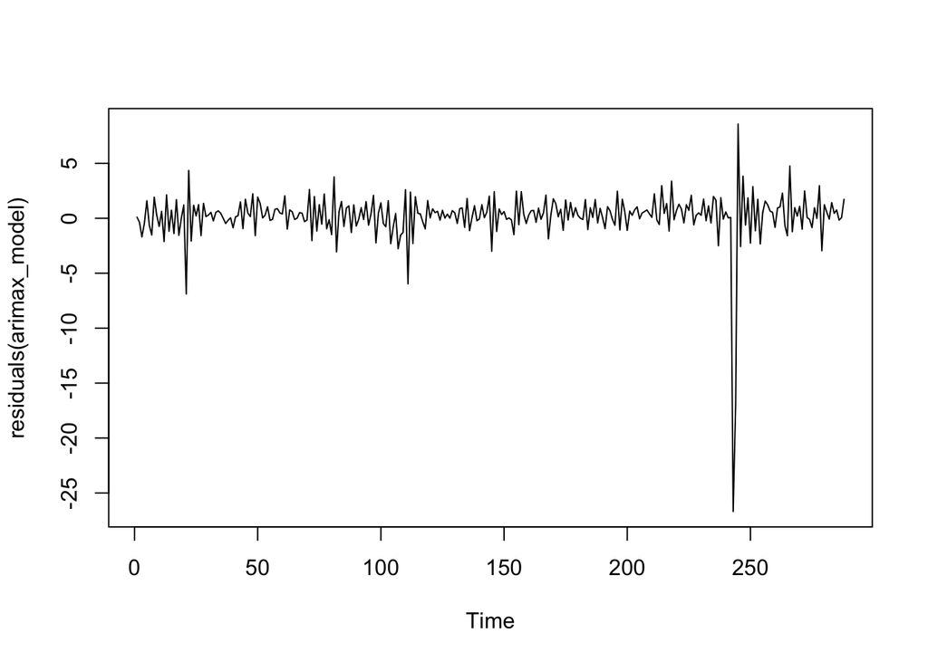

```r
plot(residuals(arimax_model))
```

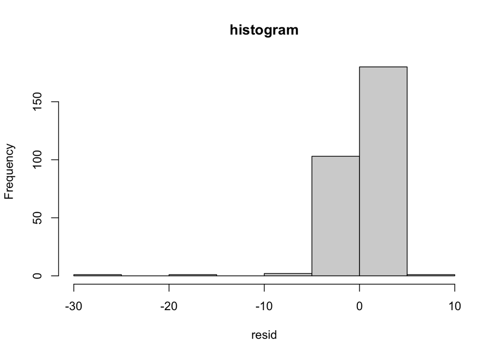

```r
# Remove missing values from residuals
clean_residuals <- residuals[!is.na(residuals)]

residuals <- clean_residuals

hist(residuals,main="histogram",xlab="resid")
```

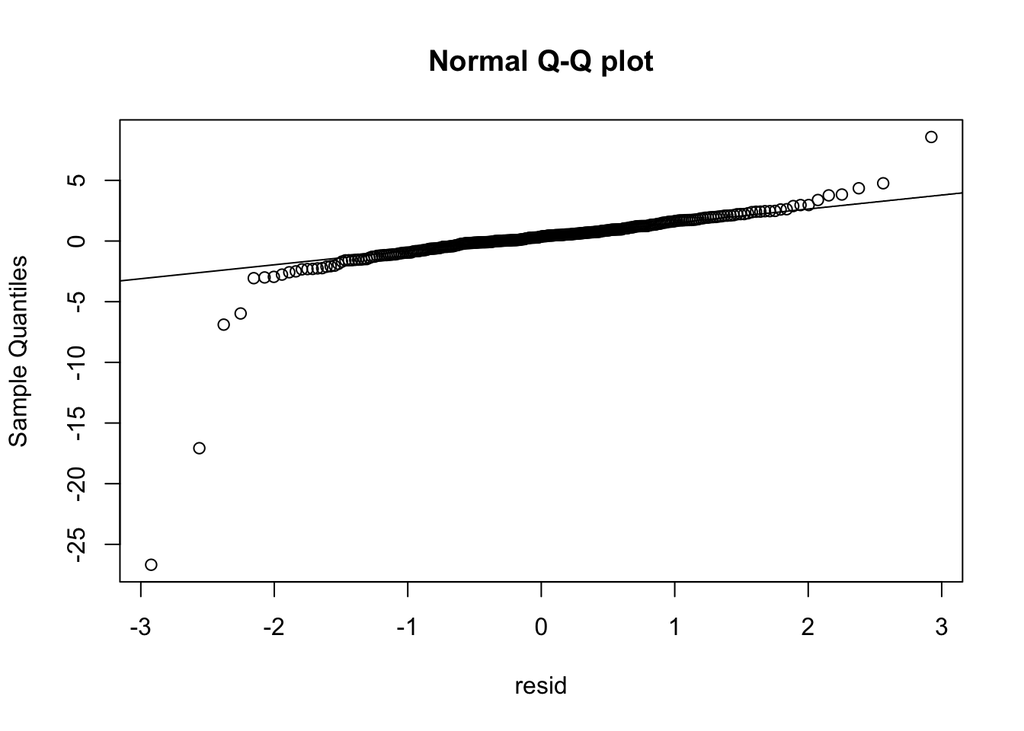

```r
qqnorm(residuals,main="Normal Q-Q plot",xlab="resid"); qqline(residuals)
```

```r
shapiro.test(residuals)
```

```
##
##  Shapiro-Wilk normality test
##
## data:  residuals
## W = 0.57667, p-value < 2.2e-16
```

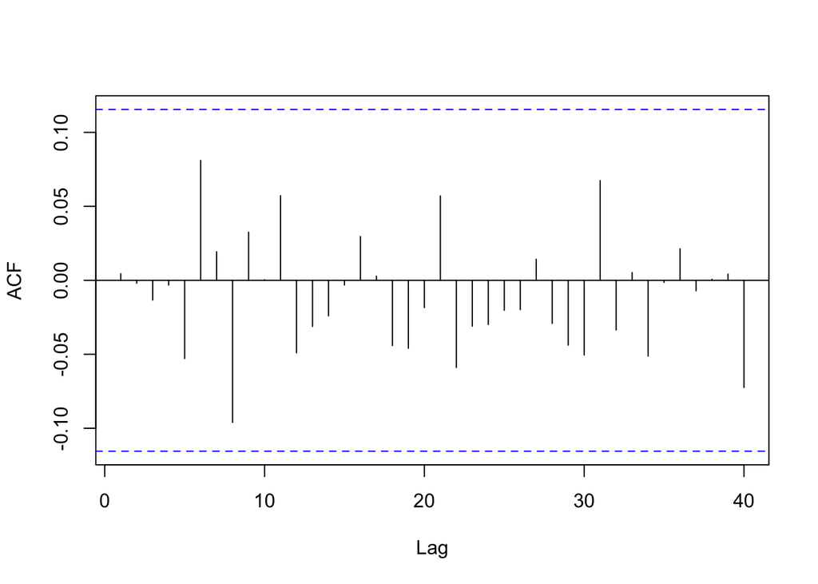

```r
acf(as.numeric(residuals), lag.max=40, main="")
```

```r
Box.test(residuals, lag=4, fitdf=1)
```

```
##
##  Box-Pierce test
##
## data:  residuals
## X-squared = 0.061094, df = 3, p-value = 0.9961
```

```r
Box.test(residuals, lag=8, fitdf=1)
```

```
##
##  Box-Pierce test
##
## data:  residuals
## X-squared = 5.5212, df = 7, p-value = 0.5966
```

```r
Box.test(residuals, lag=4, type="Ljung", fitdf=1)
```

```
##
##  Box-Ljung test
##
## data:  residuals
## X-squared = 0.062132, df = 3, p-value = 0.996
```

```r
rec.yw.fore <- predict(arimax_model, n.ahead=48)
rec.yw.fore
```

```
## $pred
## Time Series:
## Start = 289
## End = 336
## Frequency = 1
##  [1] 128.3197 127.8833 127.4789 127.1042 126.7570 126.4353 126.1372 125.8609
##  [9] 125.6050 125.3678 125.1480 124.9443 124.7556 124.5808 124.4188 124.2686
## [17] 124.1295 124.0006 123.8812 123.7705 123.6679 123.5729 123.4848 123.4032
## [25] 123.3276 123.2576 123.1926 123.1325 123.0768 123.0251 122.9772 122.9329
## [33] 122.8918 122.8537 122.8184 122.7858 122.7555 122.7274 122.7014 122.6773
## [41] 122.6549 122.6343 122.6151 122.5973 122.5808 122.5656 122.5515 122.5384
##
## $se
## Time Series:
## Start = 289
## End = 336
## Frequency = 1
##  [1]  2.404847  4.206507  5.326741  6.162151  6.827840  7.377673  7.842415
##  [8]  8.241746  8.589207  8.894607  9.165315  9.407028  9.624246  9.820588
## [15]  9.999005 10.161933 10.311402 10.449118 10.576526 10.694859 10.805171
## [22] 10.908371 11.005248 11.096484 11.182676 11.264347 11.341954 11.415903
## [29] 11.486550 11.554211 11.619167 11.681667 11.741935 11.800170 11.856549
## [36] 11.911234 11.964369 12.016082 12.066491 12.115701 12.163809 12.210900
## [43] 12.257053 12.302340 12.346826 12.390569 12.433624 12.476039
```

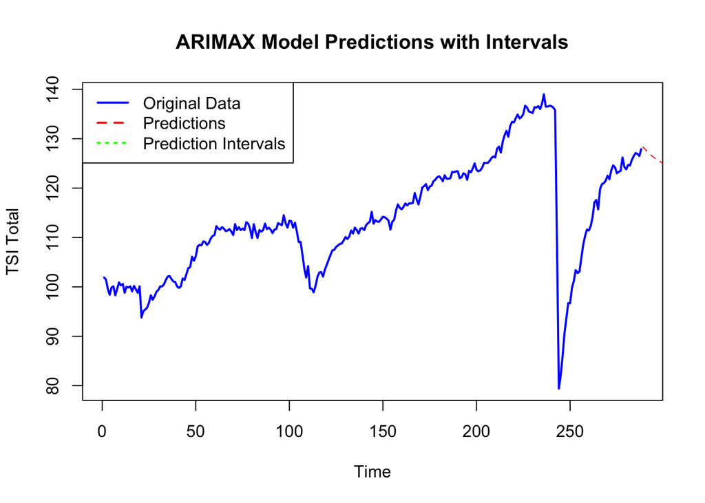

```r
plot(tsi_data$tsi_total, type = "l", col = "blue", lwd = 2,
     xlab = "Time", ylab = "TSI Total", main = "ARIMAX Model Predictions with Intervals")

# Add predictions
lines(rec.yw.fore$pred, col = "red", lty = 2)


# Add legend
legend("topleft", legend = c("Original Data", "Predictions", "Prediction Intervals"),
       col = c("blue", "red", "green"), lty = c(1, 2, 3), lwd = 2, bg = "white")
```

Above is the fitted model for the order 1, 1, 2 however the residuals are not normal but it is mostly to the sharp decline in the covid duration.

Following is the series of tests preforamed to verify the arch effect on the data

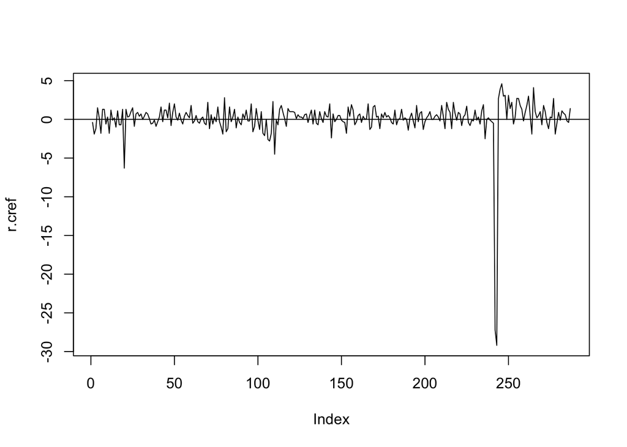

```r
r.cref <-  diff(tsi_data$tsi_total); plot(r.cref, type = "l"); abline(h=0)
```

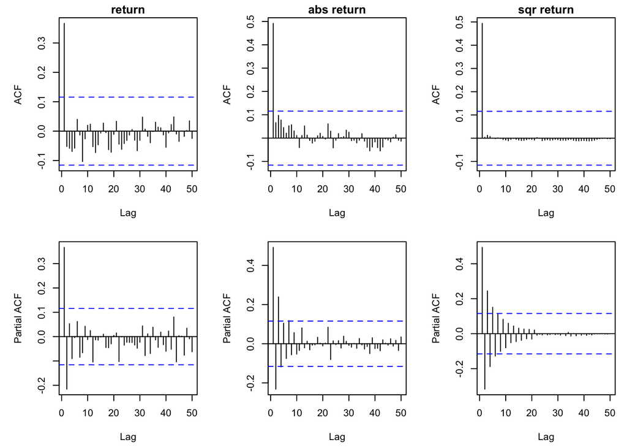

```r
par(mar=c(4.5,5,1.5,1), mfcol=c(2,3))
acf(r.cref, main="return", xlab="Lag", lag=50)
pacf(r.cref, main="", xlab="Lag", lag=50)
acf(abs(r.cref), main="abs return", xlab="Lag", lag=50)
pacf(abs(r.cref), main="", xlab="Lag", lag=50)
acf(r.cref^2, main="sqr return", xlab="Lag", lag=50)
pacf(r.cref^2, main="", xlab="Lag", lag=50)
```

```r
summary(r.cref)
```

```
##      Min.   1st Qu.    Median      Mean   3rd Qu.      Max.
## -29.20000  -0.40000   0.30000   0.09059   1.00000   4.60000
```

```r
skewness(r.cref)
```

```
## [1] -8.230584
```

```r
kurtosis(r.cref)
```

```
## [1] 84.66458
```

```
##
##  Shapiro-Wilk normality test
##
## data:  r.cref
## W = 0.42194, p-value < 2.2e-16
```

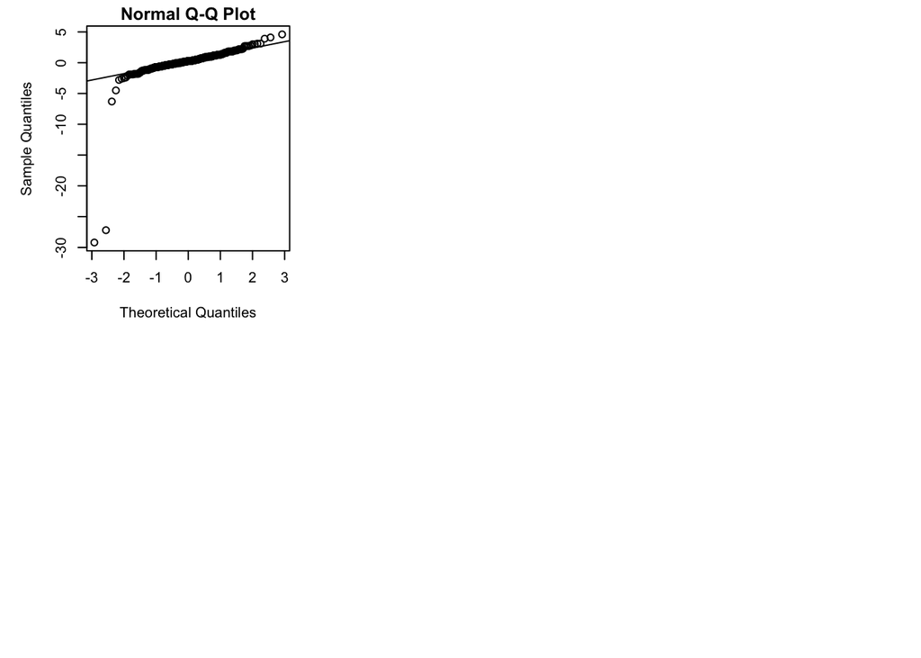

```r
qqnorm(r.cref)
qqline(r.cref)
shapiro.test(r.cref)
```

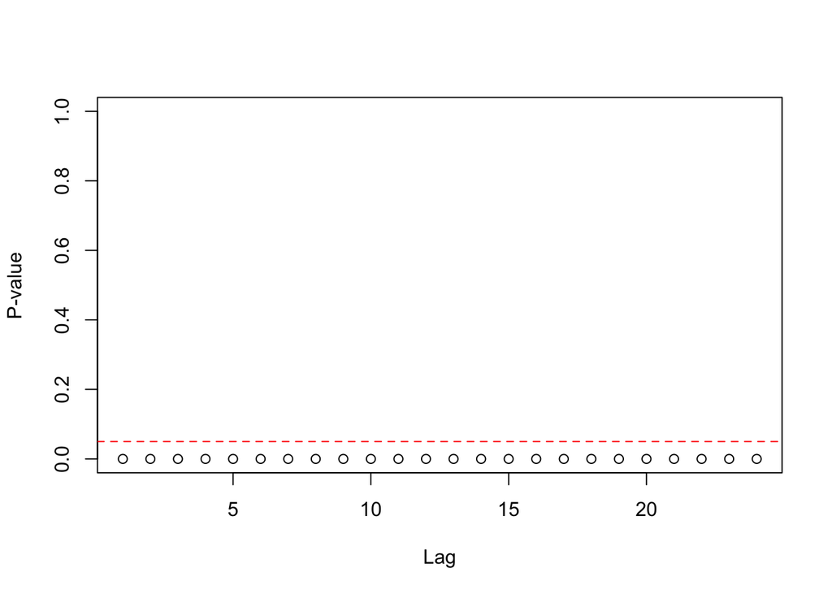

```r
McLeod.Li.test(y=r.cref)
```

After verifying the above plots and the statistical test we can determine that there is an arch effect

Following is the garch model implemented of 1, 0

```r
library(tseries)

squared_returns <- r.cref
# Fit ARCH(1) model
arch_model <- garch(squared_returns, order=c(1,0))
```

[output not shown]

```r
# Summary of the ARCH model
summary(arch_model)
```

```
##
## Call:
## garch(x = squared_returns, order = c(1, 0))
##
## Model:
## GARCH(1,0)
##
## Residuals:
##      Min       1Q   Median       3Q      Max
## -10.8761  -0.1490   0.1117   0.3725   1.7134
##
## Coefficient(s):
##     Estimate  Std. Error  t value Pr(>|t|)
## a0   6.82396          NA       NA       NA
## b1   0.05329          NA       NA       NA
##
## Diagnostic Tests:
##  Jarque Bera Test
##
## data:  Residuals
## X-squared = 88108, df = 2, p-value < 2.2e-16
##
##
##  Box-Ljung test
##
## data:  Squared.Residuals
## X-squared = 70.438, df = 1, p-value < 2.2e-16
```

```r
library(fGarch)
```

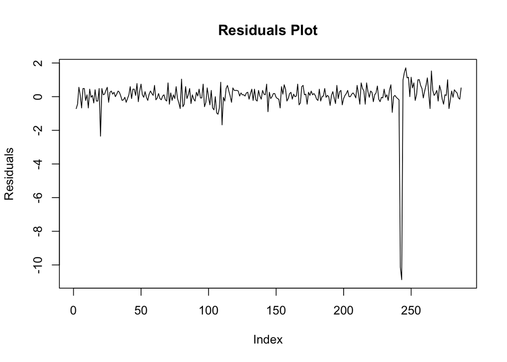

```r
residuals_square <- arch_model$residuals^2
# Identify missing values in residuals
missing_values <- is.na(residuals_square)

# Impute missing values with the mean of non-missing values
mean_residuals <- mean(residuals_square, na.rm = TRUE)
residuals_square[missing_values] <- mean_residuals

# Now you can proceed with your analysis using the updated residuals

plot(arch_model$residuals, type = "l", ylab = "Residuals", main = "Residuals Plot")
```

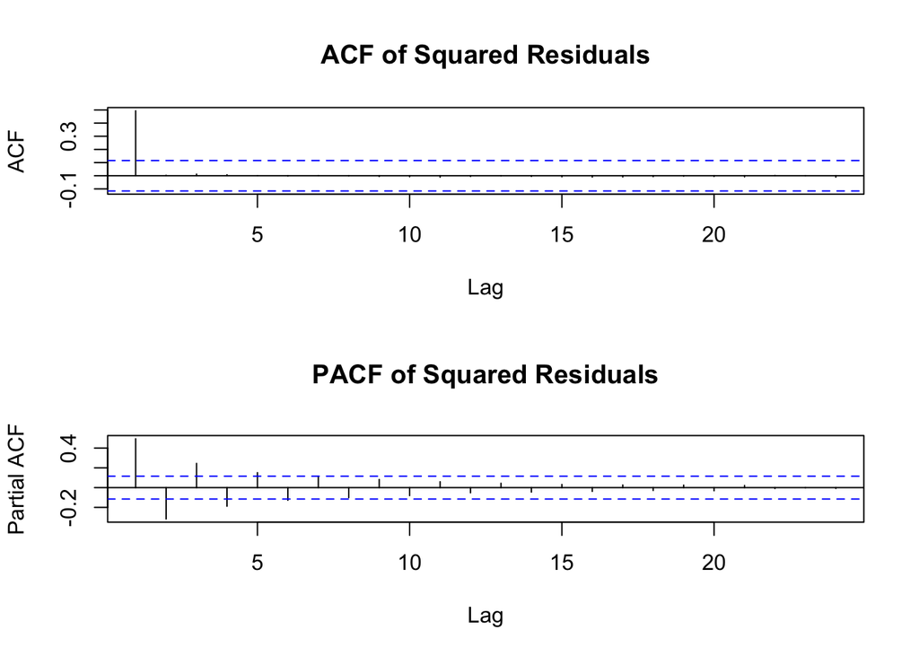

```r
# ACF and PACF of Squared Residuals
par(mfrow = c(2, 1))
acf(residuals_square, main = "ACF of Squared Residuals")
pacf(residuals_square, main = "PACF of Squared Residuals")
```

```r
# Jarque-Bera Test
jarque_bera <- jarque.bera.test(residuals_square)
print(jarque_bera)
```

```
##
##  Jarque Bera Test
##
## data:  residuals_square
## X-squared = 242995, df = 2, p-value < 2.2e-16
```

```r
# Box-Ljung Test
box_ljung <- Box.test(arch_model$residuals^2, lag = 1, type = "Ljung")
print(box_ljung)
```

```
##
##  Box-Ljung test
##
## data:  arch_model$residuals^2
## X-squared = 70.438, df = 1, p-value < 2.2e-16
```

```r
# Model Fit Statistics
print(arch_model)
```

```
##
## Call:
## garch(x = squared_returns, order = c(1, 0))
##
## Coefficient(s):
##      a0       b1
## 6.82396  0.05329
```

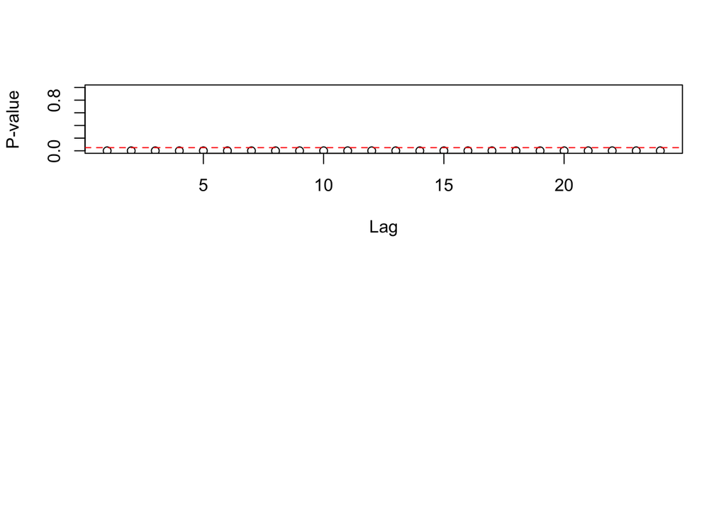

```r
McLeod.Li.test(y=arch_model$residuals)
```

After verifying the results and plots it indicates arch effect in the model.

```r
library(tseries)

# Fit ARCH(1) model
arch_model <- garch(r.cref, order=c(1,1))
```

[output not shown]

```r
# Summary of the ARCH model
summary(arch_model)
```

```
##
## Call:
## garch(x = r.cref, order = c(1, 1))
##
## Model:
## GARCH(1,1)
##
## Residuals:
##      Min       1Q   Median       3Q      Max
## -10.6622  -0.1569   0.1159   0.3857   1.5642
##
## Coefficient(s):
##     Estimate  Std. Error  t value Pr(>|t|)
## a0 6.472e+00   7.875e-01    8.218 2.22e-16 ***
## a1 1.430e-01   4.517e-02    3.166  0.00154 **
## b1 3.184e-15   1.200e-01    0.000  1.00000
## ---
## Signif. codes:  0 '***' 0.001 '**' 0.01 '*' 0.05 '.' 0.1 ' ' 1
##
## Diagnostic Tests:
##  Jarque Bera Test
##
## data:  Residuals
## X-squared = 137935, df = 2, p-value < 2.2e-16
##
##
##  Box-Ljung test
##
## data:  Squared.Residuals
## X-squared = 1.0255, df = 1, p-value = 0.3112
```

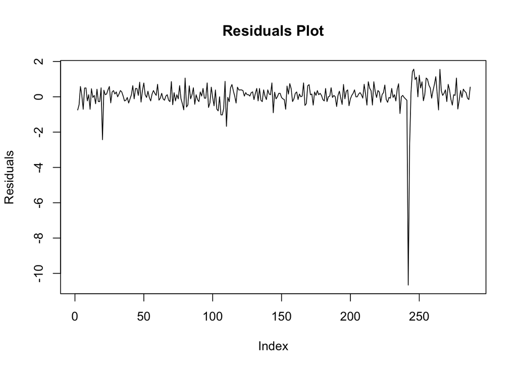

```r
library(fGarch)

residuals_square <- arch_model$residuals^2
# Identify missing values in residuals
missing_values <- is.na(residuals_square)

# Impute missing values with the mean of non-missing values
mean_residuals <- mean(residuals_square, na.rm = TRUE)
residuals_square[missing_values] <- mean_residuals

plot(arch_model$residuals, type = "l", ylab = "Residuals", main = "Residuals Plot")
```

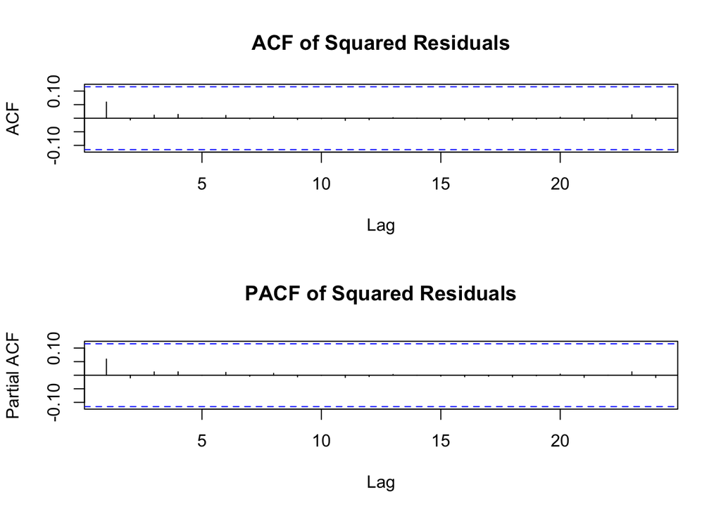

```r
# ACF and PACF of Squared Residuals
par(mfrow = c(2, 1))
acf(residuals_square, main = "ACF of Squared Residuals")
pacf(residuals_square, main = "PACF of Squared Residuals")
```

```r
# Jarque-Bera Test
jarque_bera <- jarque.bera.test(residuals_square)
print(jarque_bera)
```

```
##
##  Jarque Bera Test
##
## data:  residuals_square
## X-squared = 927388, df = 2, p-value < 2.2e-16
```

```r
# Box-Ljung Test
box_ljung <- Box.test(residuals_square, lag = 1, type = "Ljung")
print(box_ljung)
```

```
##
##  Box-Ljung test
##
## data:  residuals_square
## X-squared = 1.029, df = 1, p-value = 0.3104
```

```r
# Model Fit Statistics
print(arch_model)
```

```
##
## Call:
## garch(x = r.cref, order = c(1, 1))
##
## Coefficient(s):
##        a0         a1         b1
## 6.472e+00  1.430e-01  3.184e-15
```

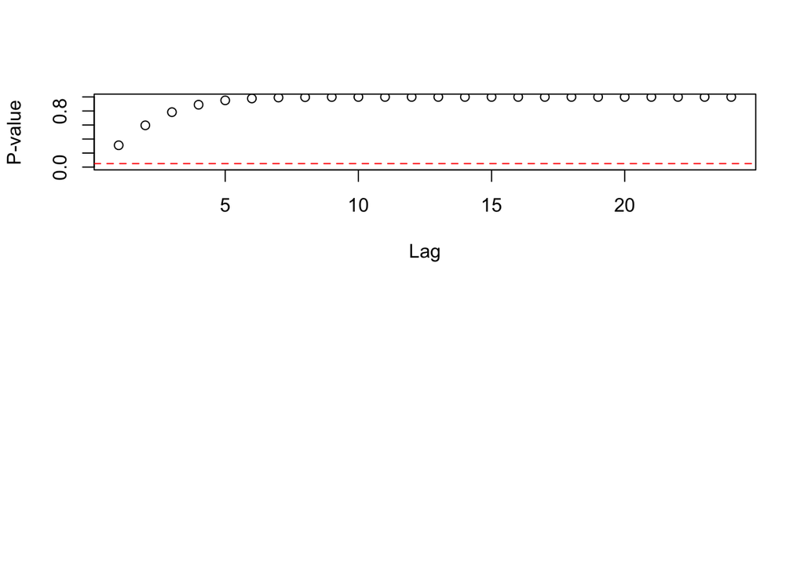

```r
McLeod.Li.test(y=arch_model$residuals)
```

After verifying the results and plots it indicates there is no arch effect in the model and the model is adequate.

```r
library(tseries)

# Assuming r.cref contains your returns
# Square the returns
squared_returns <- r.cref

# Fit ARCH(1) model
arch_model_2_0 <- garch(squared_returns, order=c(2,0))
```

[output not shown]

```r
# Summary of the ARCH model
summary(arch_model_2_0)
```

```
##
## Call:
## garch(x = squared_returns, order = c(2, 0))
##
## Model:
## GARCH(2,0)
##
## Residuals:
##      Min       1Q   Median       3Q      Max
## -10.8645  -0.1488   0.1116   0.3721   1.7115
##
## Coefficient(s):
##     Estimate  Std. Error  t value Pr(>|t|)
## a0   6.47768          NA       NA       NA
## b1   0.05137          NA       NA       NA
## b2   0.05188          NA       NA       NA
##
## Diagnostic Tests:
##  Jarque Bera Test
##
## data:  Residuals
## X-squared = 88048, df = 2, p-value < 2.2e-16
##
##
##  Box-Ljung test
##
## data:  Squared.Residuals
## X-squared = 70.191, df = 1, p-value < 2.2e-16
```

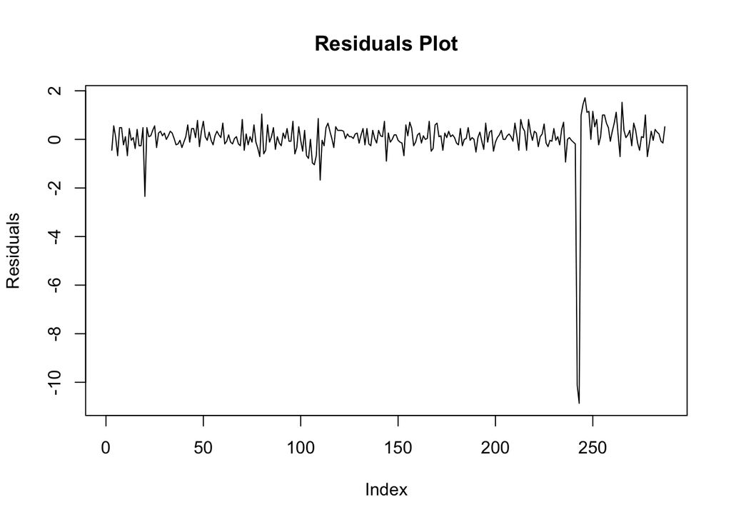

```r
library(fGarch)

residuals_square <- arch_model_2_0$residuals^2
# Identify missing values in residuals
missing_values <- is.na(residuals_square)

# Impute missing values with the mean of non-missing values
mean_residuals <- mean(residuals_square, na.rm = TRUE)
residuals_square[missing_values] <- mean_residuals

# Now you can proceed with your analysis using the updated residuals

plot(arch_model_2_0$residuals, type = "l", ylab = "Residuals", main = "Residuals Plot")
```

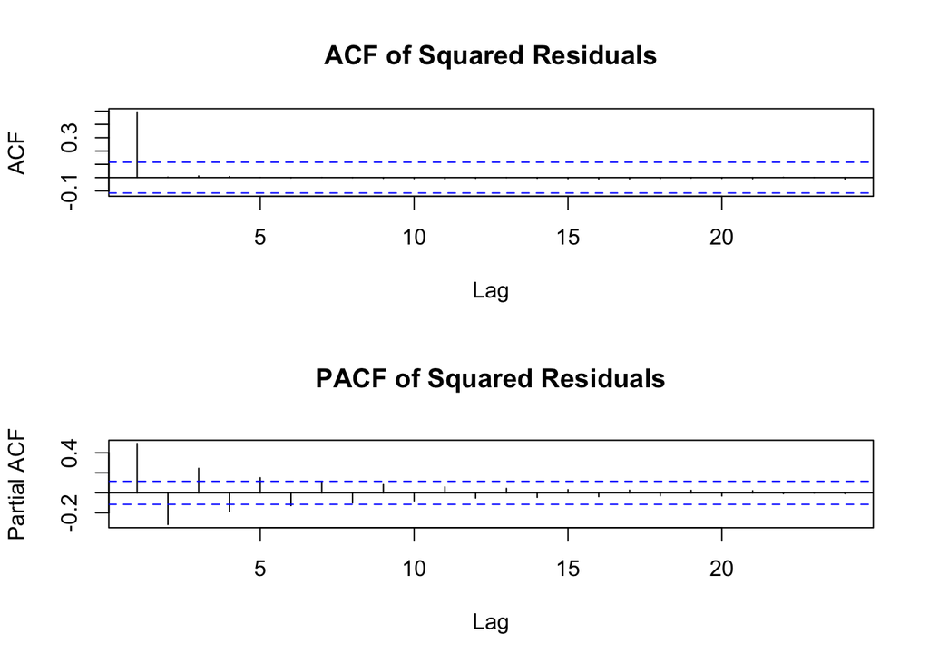

```r
# ACF and PACF of Squared Residuals
par(mfrow = c(2, 1))
acf(residuals_square, main = "ACF of Squared Residuals")
pacf(residuals_square, main = "PACF of Squared Residuals")
```

```r
# Jarque-Bera Test
jarque_bera <- jarque.bera.test(residuals_square)
print(jarque_bera)
```

```
##
##  Jarque Bera Test
##
## data:  residuals_square
## X-squared = 242974, df = 2, p-value < 2.2e-16
```

```r
# Box-Ljung Test
box_ljung <- Box.test(arch_model_2_0$residuals^2, lag = 1, type = "Ljung")
print(box_ljung)
```

```
##
##  Box-Ljung test
##
## data:  arch_model_2_0$residuals^2
## X-squared = 70.191, df = 1, p-value < 2.2e-16
```

```r
# Model Fit Statistics
print(arch_model_2_0)
```

```
##
## Call:
## garch(x = squared_returns, order = c(2, 0))
##
## Coefficient(s):
##      a0       b1       b2
## 6.47768  0.05137  0.05188
```

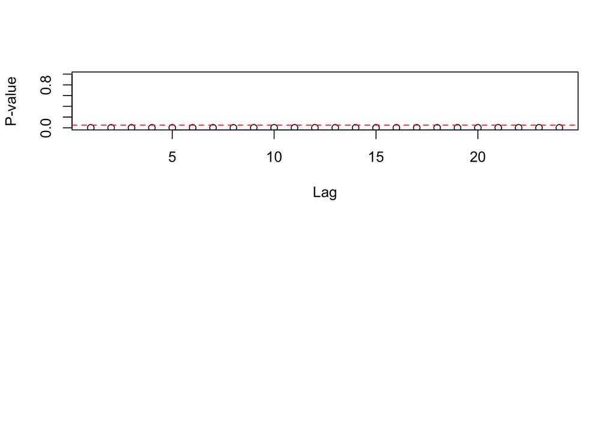

```r
McLeod.Li.test(y=arch_model_2_0$residuals)
```

After verifying the results and plots it indicates there is arch effect in the model and the model is not adequate.